# Homework 3

Jerry Slutsky

2/16/2020

# Overview

*This code is used for wrangling and visualizing the psych::bfi data set*

**First I will create an ‘id’ column for each individual in the dataset:**

```r
data<- bfi
data<- rownames_to_column(data, var = "id")
names(data)
```

```
##  [1] "id"        "A1"        "A2"        "A3"        "A4"
##  [6] "A5"        "C1"        "C2"        "C3"        "C4"
## [11] "C5"        "E1"        "E2"        "E3"        "E4"
## [16] "E5"        "N1"        "N2"        "N3"        "N4"
## [21] "N5"        "O1"        "O2"        "O3"        "O4"
## [26] "O5"        "gender"    "education" "age"
```

## Task Option 8:

### Create composite scores for the Big Five scores

```r
new.data<- data %>%
  as_tibble() %>%
  mutate(A_sum = rowSums(select(., A1:A5),na.rm = TRUE)) %>%
                mutate(N_sum = rowSums(select(., N1:N5),na.rm = TRUE)) %>%
                mutate(O_sum = rowSums(select(., O1:O5),na.rm = TRUE)) %>%
                mutate(C_sum = rowSums(select(., C1:C5),na.rm = TRUE)) %>%
                mutate(E_sum = rowSums(select(., E1:E5),na.rm = TRUE))
```

**Describe relationships among composite (sum scores) of the Big 5 Personality traits**

- I used the ‘psych’ package to create a correlation heatmap.

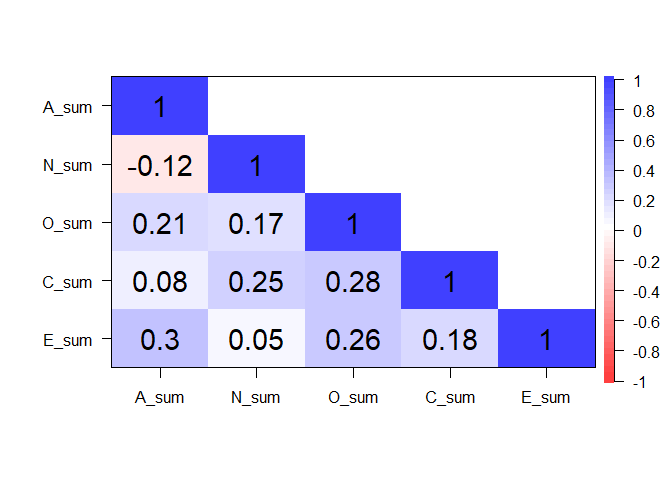

```r
corcomp <- corFiml(new.data[c(30:34)])
cor.plot(corcomp, upper = FALSE, numbers = TRUE, show.legend = TRUE)
```

**Graph of Big 5 Composite Scores**

- Created a barplot of all the Big 5 means

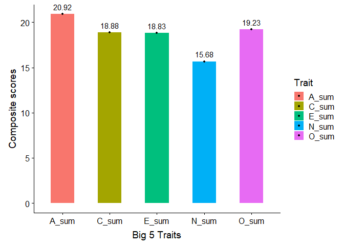

```r
fun_mean <- function(x){
  return(data.frame(y=round(mean(x),2),label=round(mean(x,na.rm=T),2)))}
new.data %>%
  gather(A_sum, N_sum, O_sum, C_sum, E_sum, key = "Trait", value = "Composite") %>%
  ggplot(aes(x=Trait, y=Composite, fill=Trait)) +
  geom_bar(stat="summary", width = 0.5, fun.y = "mean")+
  stat_summary(fun.y = mean, geom="point",colour="black", size=1) +
  stat_summary(fun.data = fun_mean, geom="text", vjust=-0.7) +
  labs(x="Big 5 Traits",y="Composite scores")
```

Agreeableness has the highest composite mean and neuroticism has the composite lowest mean

## Task Option 9:

### Does personality appear to change for different ages?

**Used facet_wrap to graph all 5 composites in one figure**

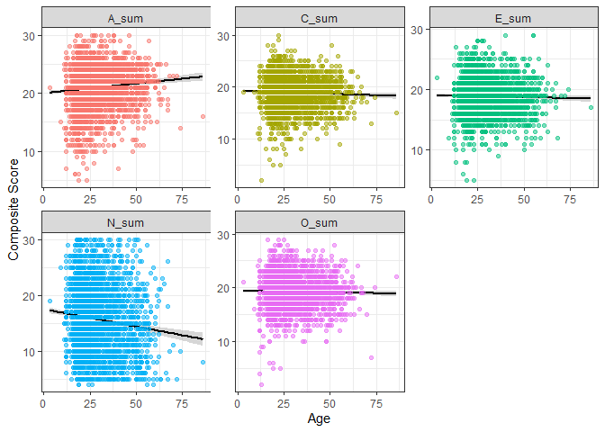

```r
new.data %>%
  gather(A_sum, N_sum, O_sum, C_sum, E_sum, key = "Trait", value = "Composite") %>%
  ggplot(aes(x = age, y = Composite, color = Trait)) +
    geom_smooth(method="lm", col="black", fun.y = "mean") +
    geom_point(alpha= .5) +
    facet_wrap(~ Trait, scales = "free") +
    theme_bw() + theme(legend.position="none") +
   labs(x="Age", y="Composite Score")
```

Looks like neuroticism and agreeableness are the only personality traits that change over time according to these data

## Task Option 10

### Explore how gender is related to the different personality variables.

**Making male = 1 and female = 2

```r
new.data$gender<- factor(new.data$gender, levels=c(1,2), labels=c("Male","Female"))
```

**Using the describeBy function to get descriptives for each trait**

```r
A<-describeBy(new.data$A_sum, group = new.data$gender)
C<-describeBy(new.data$C_sum, group = new.data$gender)
N<-describeBy(new.data$N_sum, group = new.data$gender)
O<-describeBy(new.data$O_sum, group = new.data$gender)
E<-describeBy(new.data$E_sum, group = new.data$gender)
```

**Pull means out of the describeBy function from above:**

```r
males<- c(N$`Male`$mean, A$`Male`$mean, C$`Male`$mean, O$`Male`$mean, E$`Male`$mean)
females<- c(N$`Female`$mean, A$`Female`$mean, C$`Female`$mean, O$`Female`$mean, E$`Female`$mean)
```

**Combine Means and Adding Row Names**

```r
means<-data.frame(males,females, check.names = FALSE,
                  check.rows = FALSE,
                  row.names=c("N","A","C","O","E"))
```

**Printing Means of Males and Females in Table Format:**

```r
knitr::kable(means)
```

|  | males | females |
| --- | --- | --- |
| N | 14.63547 | 16.18288 |
| A | 20.25789 | 21.24189 |
| C | 19.01197 | 18.81818 |
| O | 19.38629 | 19.14620 |
| E | 18.87051 | 18.81074 |

Males scored higher on Conscientiousness, Openness, and Extroversion. Females scored higher on Neuroticism and Agreeableness.